# Final Project Joslyn Kelly

Joslyn Fu and Kelly Yuan

12/9/2020

## Project Overview

From the previous extinction module, we’re pretty sure that the sixth mass extinction is around the corner. According to its definition, extinction usually begins with the loss in abundance of individuals that can result in compositional and functional changes of ecosystems. This assignment would be based on the research done by Kenneth V. Rosenberg, “Decline of the North American avifauna.” We would use the data his team once used and answer the following three questions: 1. Is the population of birds really declining? To what extent? 2. If the answer to the first question is yes, is every famliy of birds encountering the same decline? In other words, is every species being affected equally by this changing environment? 3. What’s the effect of declining of birds on other related species?

## Data Import

In the research conducted by Kenneth V. Rosenberg, they used these following two datasets:

```r
data <- read_excel("aaw1313_Data_S1.xlsx")
data
```

```
## # A tibble: 529 x 24
##    species sci_name  sort Breeding.Biome Winter.Biome Family bird.group Migrate
##    <chr>   <chr>    <dbl> <chr>          <chr>        <chr>  <chr>      <chr>
##  1 Abert'… Melozon…  1817 Aridlands      Southwester… Passe… landbird   R
##  2 Acadia… Empidon…  1303 Eastern Forest Mexico-Cent… Tyran… landbird   M
##  3 Acorn … Melaner…   939 Western Forest Widespread   Picid… landbird   R
##  4 Alder … Empidon…  1304 Boreal Forest  South Ameri… Tyran… landbird   M
##  5 Allen'… Selasph…   342 Aridlands      Mexico-Cent… Troch… landbird   M
##  6 Americ… Recurvi…   444 Wetland        Widespread   Recur… shorebird  M
##  7 Americ… Botauru…   727 Wetland        Temperate N… Ardei… waterbird  M
##  8 Americ… Anas ru…    49 Wetland        Temperate N… Anati… waterfowl  M
##  9 Americ… Fulica …   435 Wetland        Widespread   Ralli… waterbird  M
## 10 Americ… Corvus …  1395 Habitat Gener… Temperate N… Corvi… landbird   M
## # … with 519 more rows, and 16 more variables: AI <chr>, native <chr>,
## #   popest <dbl>, popestlci <dbl>, popestuci <dbl>, first_year_popest <dbl>,
## #   last_year_popest <dbl>, Pop.source <chr>, Trajectory_data_source <chr>,
## #   Trajectory_firstyear <dbl>, Trajectory_lastyear <dbl>, Loss_med <dbl>,
## #   Loss_lci <dbl>, Loss_uci <dbl>, Loss_lqrt <dbl>, Loss_uqrt <dbl>
```

```r
summary <- read_excel("aaw1313_Data_S2.xlsx")
```

```
## * `` -> ...2
## * `` -> ...3
## * `` -> ...4
## * `` -> ...5
## * `` -> ...6
## * ...
```

```r
summary
```

```
## # A tibble: 400 x 11
##    `see "Definition… ...2  ...3  ...4  ...5  ...6  ...7  ...8  ...9  ...10 ...11
##    <chr>             <chr> <chr> <chr> <chr> <chr> <chr> <chr> <chr> <chr> <chr>
##  1 Species           sci_… sort  group PopU… PopL… PopU… Time… Time… Dist… Pair…
##  2 Abert's Towhee    Melo… 1817  land… 8902… 4295… 1469… 0.92… 3.27… 125   2
##  3 Acadian Flycatch… Empi… 1303  land… 5227… 4728… 5829… 0.21… 7.58… 125   2
##  4 Acorn Woodpecker  Mela… 939   land… 2226… 1452… 3390… 0.26… 3.29… 200   1.75
##  5 Alder Flycatcher  Empi… 1304  land… 1179… 9938… 1411… 0.27… 1.42… 125   2
##  6 Allen's Hummingb… Sela… 342   land… 1484… 3480… 4475… 0.29… 2.29… 50    1.25
##  7 American Crow     Corv… 1395  land… 2804… 2644… 2963… 0.50… 3.58… 400   1.75
##  8 American Dipper   Cinc… 1514  land… 1519… 1140… 2001… 0.12… 2.23… 125   1.75
##  9 American Goldfin… Spin… 1771  land… 4409… 4155… 4676… 0.31… 1.88… 125   1.25
## 10 American Kestrel  Falc… 998   land… 2827… 2564… 3116… 0.29… 6.69… 200   1.25
## # … with 390 more rows
```

However, these two datasets have a lot of overlaps. We will analyze our problems based on the first dataset.

## Question 1: Is the population of birds really declining? To what extent?

We now have a very large dataset. To make our moves in the future simple, let’s choose some factors to analyze:

```r
simple_data <- data %>% select(1,4,6,7,8,9,10,11,14,15,20)
simple_data
```

```
## # A tibble: 529 x 11
##    species Breeding.Biome Family bird.group Migrate AI    native popest
##    <chr>   <chr>          <chr>  <chr>      <chr>   <chr> <chr>   <dbl>
##  1 Abert'… Aridlands      Passe… landbird   R       other native 8.90e5
##  2 Acadia… Eastern Forest Tyran… landbird   M       other native 5.23e6
##  3 Acorn … Western Forest Picid… landbird   R       other native 2.23e6
##  4 Alder … Boreal Forest  Tyran… landbird   M       other native 1.18e8
##  5 Allen'… Aridlands      Troch… landbird   M       other native 1.48e6
##  6 Americ… Wetland        Recur… shorebird  M       other native 4.50e5
##  7 Americ… Wetland        Ardei… waterbird  M       other native 2.51e6
##  8 Americ… Wetland        Anati… waterfowl  M       other native 5.84e5
##  9 Americ… Wetland        Ralli… waterbird  M       other native 5.52e6
## 10 Americ… Habitat Gener… Corvi… landbird   M       other native 2.80e7
## # … with 519 more rows, and 3 more variables: first_year_popest <dbl>,
## #   last_year_popest <dbl>, Loss_med <dbl>
```

The last column “loss_med” is the estimated change in number of breeding individuals over the trend period (usually 1970-2017), based on a combination of current population estimates and long-term trajectories. Median of the posterior distribution from the hierarchical Bayesian model. Now, let’s do an average on this over all speices, grouped by the group of bird.

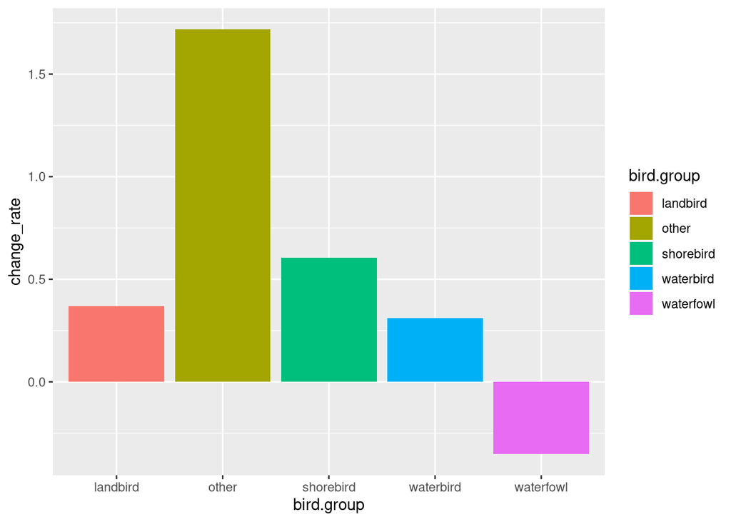

```r
loss <- simple_data %>%
  group_by(bird.group) %>%
  summarize(mean_loss = mean(Loss_med),mean_pop_size = mean(popest)) %>%
  mutate(change_rate = mean_loss/mean_pop_size) %>%
  ggplot(aes(x = bird.group,y = change_rate,fill=bird.group)) + geom_bar(stat = "identity")
loss
```

Based on this graph, we are pretty sure that the mean_loss is very large for most groups of birds, except for the waterfowl. We suspect that waterfowls’s amount is increasing because for geese and ducks, people might raise them manually.

## Question 2: Is the decline of populations even among all speices? Are there certain species that experience more effect than others?

Let’s dig deeper based on what we’ve done in question 1. We would group the data by family to make everything easy to read. To get the proportion of loss, we divide the mean_loss by the total mean_loss instead of 3.2 billiion, which is the amount given in Rosenberg’s paper.

```r
family_loss <- simple_data %>%
  group_by(Family)%>%
  summarize(mean_loss = mean(Loss_med), number=n()) %>%
  filter(mean_loss > 0) %>%
  mutate(proportion_of_loss = mean_loss/sum(mean_loss)) %>%
  arrange(desc(proportion_of_loss))
family_loss
```

```
## # A tibble: 38 x 4
##    Family         mean_loss number proportion_of_loss
##    <chr>              <dbl>  <int>              <dbl>
##  1 Alaudidae     182481347.      1             0.308
##  2 Passeridae    165381264.      2             0.279
##  3 Sturnidae      83350978.      1             0.141
##  4 Icteridae      24480085.     18             0.0413
##  5 Passerellidae  22557658.     38             0.0380
##  6 Parulidae      13939634.     44             0.0235
##  7 Fringillidae   11198698.     13             0.0189
##  8 Regulidae       9226796.      2             0.0156
##  9 Calcariidae     8200321.      5             0.0138
## 10 Hirundinidae    7987501.      8             0.0135
## # … with 28 more rows
```

The proportion is so small that it’s very uncomfortable for us to see.

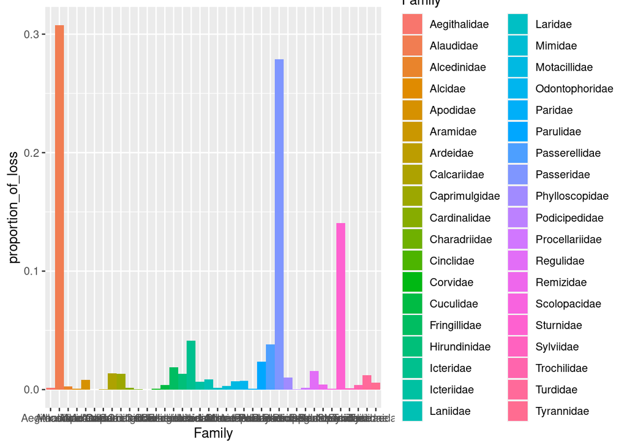

```r
family_loss %>%
  ggplot(aes(x=Family, y=proportion_of_loss,fill=Family)) + geom_bar(width = 1, stat = "identity")
```

There are some families that experience population gains. Let’s list them out. As what we did before for the family_loss, we divide the mean_gain by the total gains, calculated by sum(mean_gain).

```r
family_gain <- simple_data %>%
  group_by(Family)%>%
  summarize(mean_loss = mean(Loss_med), number=n()) %>%
  filter(mean_loss < 0) %>%
  mutate(mean_gain = -mean_loss, proportion_of_gain = mean_gain/sum(mean_gain)) %>%
  arrange(desc(proportion_of_gain))
family_gain
```

```
## # A tibble: 29 x 5
##    Family         mean_loss number mean_gain proportion_of_gain
##    <chr>              <dbl>  <int>     <dbl>              <dbl>
##  1 Polioptilidae -16030625.      2 16030625.             0.344
##  2 Vireonidae     -7445028.     12  7445028.             0.160
##  3 Cathartidae    -4695039.      2  4695039.             0.101
##  4 Bombycillidae  -4056809.      2  4056809.             0.0872
##  5 Sittidae       -3590511.      4  3590511.             0.0771
##  6 Certhiidae     -2487358.      1  2487358.             0.0534
##  7 Troglodytidae  -1316479.     10  1316479.             0.0283
##  8 Phasianidae    -1153999.     12  1153999.             0.0248
##  9 Anatidae        -767549.     42   767549.             0.0165
## 10 Gruidae         -693633.      1   693633.             0.0149
## # … with 19 more rows
```

As before, let’s try to do the graph for family_gain

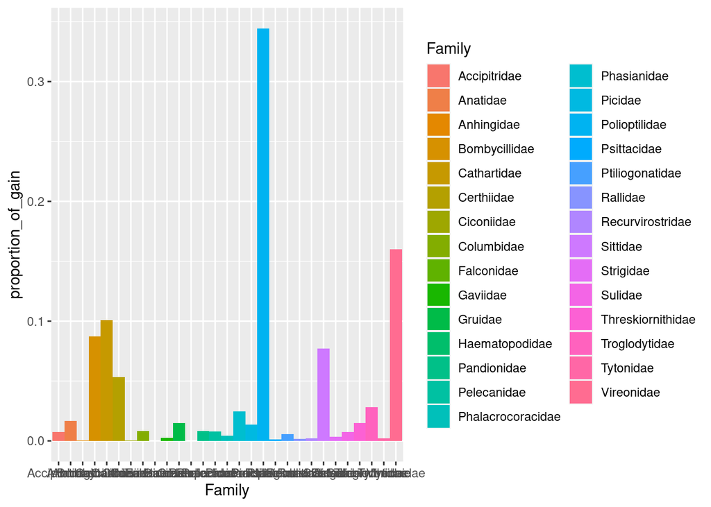

```r
family_gain %>%
  ggplot(aes(x=Family, y=proportion_of_gain,fill=Family)) + geom_bar(width = 1, stat = "identity")
```

Therefore, apparently not every species is affected equally by this changing environment. There are species that suffered from loss, and also species accumulated more population.

## Question 3: What’s the effect of declining of birds on other related species?

We further explore the relationship between birds and insects.

In our dataset, there’s one column “AI” that identifies species in the “Aerial Insectivore” group, birds that capture flying insects while in flight.

```r
AI <- simple_data  %>%
  group_by(AI) %>%
  summarize (sum_loss = sum(Loss_med), mean = mean(Loss_med))
AI
```

```
## # A tibble: 2 x 3
##   AI       sum_loss     mean
##   <chr>       <dbl>    <dbl>
## 1 AI     159780554. 6145406.
## 2 other 2770381476. 5507717.
```

The total loss of AI group is less than that of the other group; however, the mean loss is larger for AI. This means that for every species within AI group, they encounter more loss of populations.

From the article “Plummeting insect numbers ‘threaten collapse of nature’,” we surprisingly find that more than 40% of insect species are declining and a third are endangered. The rate of extinction is eight times faster than that of mammals, birds and reptiles. The total mass of insects is falling by a precipitous 2.5% a year, according to the best data available, suggesting they could vanish within a century. This contradicts with our findings from the extinction module, where we found that the rate of decline for birds is higher than that of insects. Therefore, we requires further investigation with more precise data to learn about the relationship between birds and insects.